# Reproducible Research Project Week 2

Javier S

27 de noviembre de 2021

1. Let’s read in the data of the fitbit wearables so we can start working with it.

```r
setwd("C:/Users/javie/OneDrive/Documents/Coursera/Reproducible Research")
activity_data <- read.csv(file = "activity.csv", header = TRUE, sep = ",")
```

2. Now we will create a histogram for the number of steps taken each day.

```r
library(dplyr)
```

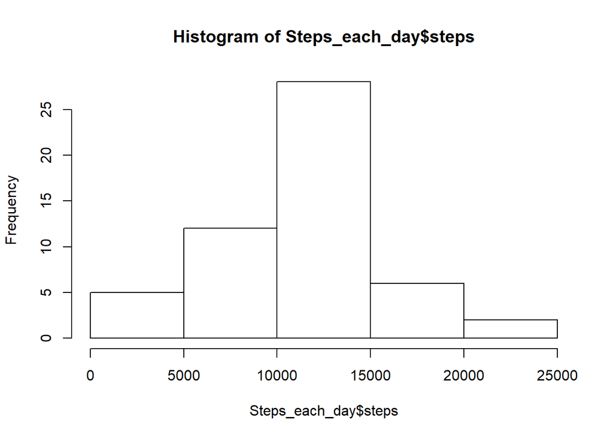

```r
Steps_each_day <- aggregate(steps ~ date, activity_data, sum, na.rm = TRUE)
hist(Steps_each_day$steps)
```

3. Next, we calculate the mean and median for the number of steps each day

```r
Summary_Statistics <- summarise(Steps_each_day, Mean_Steps = mean(steps),
                                Median_Steps = median(steps))
Summary_Statistics
```

```
##   Mean_Steps Median_Steps
## 1   10766.19        10765
```

4. Once we’ve reached this point, let’s plot a timeline with the number of steps for each time interval

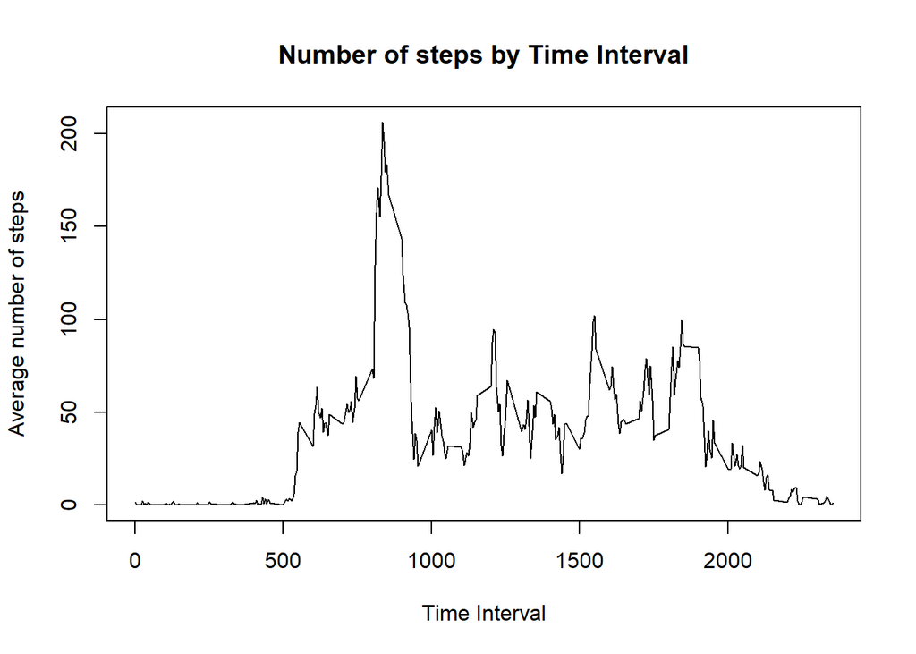

```r
Steps_by_Interval<-aggregate(steps~interval, data=activity_data, mean, na.rm=TRUE)



plot(steps~interval, data=Steps_by_Interval, type="l", xlab = "Time Interval", ylab = "Average number of steps", main = "Number of steps by Time Interval")
```

5. Now, let’s find out which time interval averages the maximum number of steps

```r
Maximum_Interval <- as.numeric(Steps_by_Interval[which.max(Steps_by_Interval$steps),]$interval)


Maximum_Interval
```

```
## [1] 835
```

6. Let’s find a strategy for imputing the missing values and continue our calculations including thos e missing values.

```r
Total_missing_Values <- sum(is.na(activity_data$steps))
Total_missing_Values
```

```
## [1] 2304
```

Next we code a function that will return for each interval the means number of steps for that interval. This will e our strategy for imputing missing values.

```r
getMeanSteps_by_Interval<-function(interval){
    Steps_by_Interval[Steps_by_Interval$interval==interval,]$steps
}
```

Finally we assign to each NA the corresponding number of steps based on the time interval.

```r
activityDatawithoutNA<-activity_data
for(i in 1:nrow(activityDatawithoutNA)){
    if(is.na(activityDatawithoutNA[i,]$steps)){
        activityDatawithoutNA[i,]$steps <- getMeanSteps_by_Interval(activityDatawithoutNA[i,]$interval)
    }
}
```

7. Now that we have imputed a value to the missing values, we make the histogram of the new data

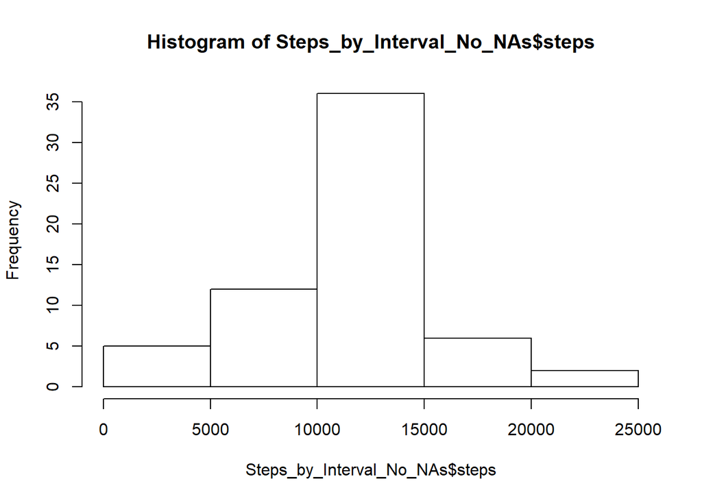

```r
Steps_by_Interval_No_NAs <- aggregate(steps ~ date, activityDatawithoutNA, sum)

hist(Steps_by_Interval_No_NAs$steps)
```

8. WE try to find the differences between weekdays and weekends

```r
activityDatawithoutNA$date <- as.Date(activityDatawithoutNA$date, format="%Y-%m-%d")
activityDatawithoutNA$day <- weekdays(activityDatawithoutNA$date)
for (i in 1:nrow(activityDatawithoutNA)) {
    if (activityDatawithoutNA[i,]$day %in% c("sæ¼ã¸±bado","domingo")) {
        activityDatawithoutNA[i,]$day<-"weekend"
    }
    else{
        activityDatawithoutNA[i,]$day<-"weekday"
    }
}

Steps_weekend_Vs_weekday <- aggregate(activityDatawithoutNA$steps ~ activityDatawithoutNA$interval
                                       + activityDatawithoutNA$day, data = activityDatawithoutNA,
                                        FUN = mean)
```

Now we plot both panels, weekday and weekend using facet_wrap

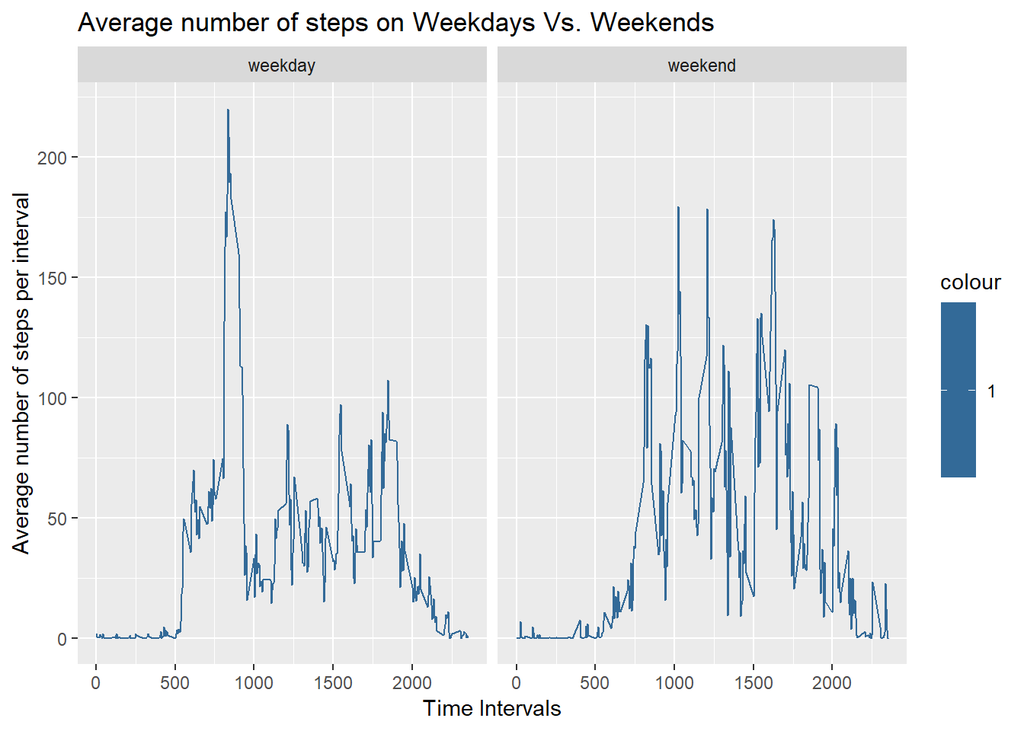

```r
names(Steps_weekend_Vs_weekday) <- c("interval", "day", "steps")
library(ggplot2)
Weekdays_Vs_Weekends_Plot <- qplot(data = Steps_weekend_Vs_weekday,x = interval ,y =  steps,
                geom = "line", main = "Average number of steps on Weekdays Vs. Weekends",
                xlab = "Time Intervals",
                ylab = "Average number of steps per interval",
                col = 1)

Weekdays_Vs_Weekends_Plot + facet_wrap(~ day)
```

9. We check that all code chunks are there and… task completed!!!